# Analysez les ventes d'une librairie avec Python

### Etape 2.4 - Tops et flops des produits commercialisés

```python
# Créer un dataframe avec le top 20 des produits les plus vendus
# .groupby('id_prod').size() retourne une series où l’index est id_prod et la valeur est le nombre de fois que chaque produit (id_prod) apparaît dans le dataframe df
sales_by_product = df.groupby('id_prod').size()
top_20_products = sales_by_product.nlargest(20)
top_20_products = top_20_products.reset_index()
top_20_products.columns = ['id_prod', 'units_sold']
top_20_products
```

|  | id_prod | units_sold |
| --- | --- | --- |
| 0 | 1_369 | 2340 |
| 1 | 1_417 | 2269 |
| 2 | 1_414 | 2246 |
| 3 | 1_498 | 2202 |
| 4 | 1_425 | 2163 |
| 5 | 1_403 | 2040 |
| 6 | 1_413 | 2036 |
| 7 | 1_412 | 2014 |
| 8 | 1_406 | 2003 |
| 9 | 1_407 | 2001 |
| 10 | 1_396 | 1999 |
| 11 | 1_398 | 1975 |
| 12 | 1_395 | 1953 |
| 13 | 1_400 | 1906 |
| 14 | 1_392 | 1899 |
| 15 | 1_376 | 1870 |
| 16 | 1_385 | 1870 |
| 17 | 1_388 | 1858 |
| 18 | 1_397 | 1858 |
| 19 | 1_383 | 1857 |

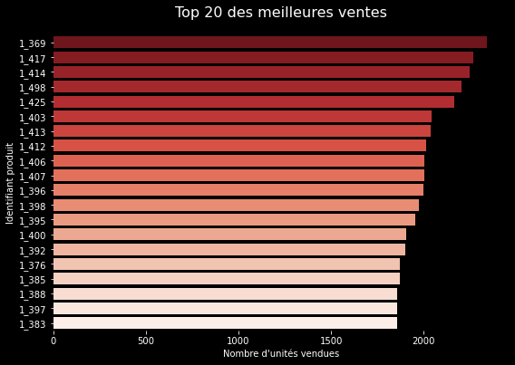

```python
# Visualisation du top 20 à l'aide d'un barplot
plt.figure(figsize=(9,6))
palette = sns.color_palette("Reds", n_colors=20).as_hex()[::-1]
sns.barplot(data=top_20_products, y='id_prod', x='units_sold', orient='h', palette=palette)
plt.title("Top 20 des meilleures ventes", fontsize=16, loc='center', pad=20)
plt.ylabel("Identifiant produit")
plt.xlabel('Nombre d\'unités vendues')
plt.box(False)
plt.show()
```

```python
# Lister les 20 produits les moins vendus dans un dataframe et l'afficher
flop_20_products = sales_by_product.nsmallest(20)
flop_20_products = flop_20_products.reset_index()
flop_20_products.columns = ['id_prod', 'units_sold']
flop_20_products
```

|  | id_prod | units_sold |
| --- | --- | --- |
| 0 | 0_1151 | 1 |
| 1 | 0_1284 | 1 |
| 2 | 0_1379 | 1 |
| 3 | 0_1498 | 1 |
| 4 | 0_1539 | 1 |
| 5 | 0_1601 | 1 |
| 6 | 0_1633 | 1 |
| 7 | 0_1683 | 1 |
| 8 | 0_1728 | 1 |
| 9 | 0_2201 | 1 |
| 10 | 0_541 | 1 |
| 11 | 0_549 | 1 |
| 12 | 0_807 | 1 |
| 13 | 0_833 | 1 |
| 14 | 0_886 | 1 |
| 15 | 2_23 | 1 |
| 16 | 2_81 | 1 |
| 17 | 2_98 | 1 |
| 18 | 0_1116 | 2 |
| 19 | 0_1120 | 2 |

Sans trop de surprise, on retrouve dans le top 20 uniquement des produits de la catégorie 1, tandis que seul des produits des catégories 0 et 2 figurent dans le flop 20.

### Etape 2.5 - Répartition du chiffre d'affaires par produit

```python
# Créer un dataframe pour analyser la répartition du CA par produit (en incluant les 4 outliers)
sales_by_product = df.groupby('id_prod').agg({'price': 'sum', 'categ': 'first'})
sales_by_product = sales_by_product.reset_index()
sales_by_product.rename(columns={'price': 'total_sales_of_product'}, inplace=True)
sales_by_product = sales_by_product.sort_values(by='total_sales_of_product')
sales_by_product.head()
```

|  | id_prod | total_sales_of_product | categ |
| --- | --- | --- | --- |
| 595 | 0_1539 | 0.99 | 0 |
| 313 | 0_1284 | 1.38 | 0 |
| 719 | 0_1653 | 1.98 | 0 |
| 1784 | 0_541 | 1.99 | 0 |
| 665 | 0_1601 | 1.99 | 0 |

```python
# Créer une colonne CA cumulé
sales_by_product['cumulative_sales'] = sales_by_product['total_sales_of_product'].cumsum()
# Ajouter une colonne proportion cumulée du CA, obtenue en divisant la colonne CA cumulé par le chiffre d'affaires total
sales_by_product['cumulative_proportion_of_sales'] = sales_by_product['cumulative_sales']/sales_by_product['total_sales_of_product'].sum()
sales_by_product
```

|  | id_prod | total_sales_of_product | categ | cumulative_sales | cumulative_proportion_of_sales |
| --- | --- | --- | --- | --- | --- |
| 595 | 0_1539 | 0.99 | 0 | 0.99 | 8.231025e-08 |
| 313 | 0_1284 | 1.38 | 0 | 2.37 | 1.970458e-07 |
| 719 | 0_1653 | 1.98 | 0 | 4.35 | 3.616663e-07 |
| 1784 | 0_541 | 1.99 | 0 | 6.34 | 5.271182e-07 |
| 665 | 0_1601 | 1.99 | 0 | 8.33 | 6.925701e-07 |
| ... | ... | ... | ... | ... | ... |
| 3152 | 2_209 | 56971.86 | 2 | 11737290.11 | 9.758579e-01 |
| 3034 | 2_102 | 60736.78 | 2 | 11798026.89 | 9.809077e-01 |
| 3045 | 2_112 | 65407.76 | 2 | 11863434.65 | 9.863458e-01 |
| 3070 | 2_135 | 69334.95 | 2 | 11932769.60 | 9.921104e-01 |
| 3096 | 2_159 | 94893.50 | 2 | 12027663.10 | 1.000000e+00 |

3265 rows × 5 columns

```python
# Créer une fonction courbe de lorenz qui va afficher les inégalités dans la répartition du CA entre les différents produits

# L'argument df_cum_y doit être une colonne de proportion (ou fréquence) cumulée
def lorenz_curve(df, df_cum_y, x_label, y_label, title):
    # n = nombre d'éléments de la colonne du dataframe
    n = len(df[df_cum_y])

    # Créer un array avec autant de 0 qu'il y a d'éléments dans la colonne du dataframe.
    # Chaque zéro est associé à son élément et signifie que l'élément (ou individu) ne possède (ou génère) rien.
    # La courbe de lorenz commence à 0. On insère donc un 0 au début de chaque array, d'où le +1
    perfect_inequality = np.zeros(n+1)

    # numpy.linspace(start, stop, num=50, endpoint=True, retstep=False, dtype=None, axis=0) => Returns evenly spaced numbers over a specified interval.
    # Lister autant de fractions qu'il y a d'éléments dans la colonne. Si n est 5, np.linspace(0, 1, n+1) renvoie un 1d array contenant 0.2, 0.4, 0.6, 0.8, et 1
    # soit des fractions représentant une distribution parfaitement égale : le premier élément possède 20 %, le premier et le deuxième possèdent ensemble 40 %, etc....
    perfect_equality = np.linspace(0, 1, n+1)

    # Même principe qu'au-dessus.
    fractions = np.linspace(0, 1, n+1)

    cum_y_array = np.insert(df[df_cum_y].values, 0, 0) # on insère un 0 au début de l'array contenant les proportions cumulées
    # print(cum_y_array)

    lorenz_curve_y_values = df[df_cum_y].values # la méthode .values renvoie les valeurs dans un np.array
    lorenz_curve_x_values = np.array(range(1, n+1)) / n
    B = np.trapz(lorenz_curve_y_values, x = lorenz_curve_x_values)  # aire sous la courbe de Lorenz
    A = 0.5 - B  # aire entre la courbe de Lorenz et la droite d'équirépartition (première bissectrice)
    gini_index = round(A * 2,2) # indice de Gini

    plt.figure(figsize=(9,6))
    plt.plot(fractions, perfect_equality, color='green')
    plt.plot(fractions, perfect_inequality, color='red')
    plt.plot(fractions, cum_y_array, color='gold')
    plt.title(title, fontsize=16, pad=20)
    plt.xlabel(x_label)
    plt.ylabel(y_label)
    plt.grid()
    plt.legend(['Répartition parfaitement égale','Parfaite inégalité',f'Courbe de Lorenz | Indice de Gini : {gini_index}'], bbox_to_anchor=(1.075, -0.15), ncol=4)
    plt.show()
    return gini_index
```

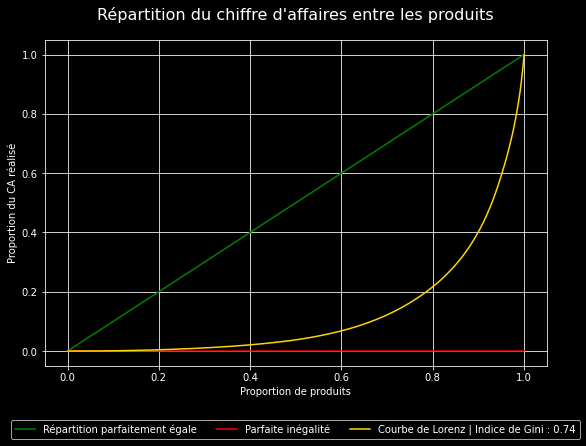

```
0.74
```

```python
# Visualiser la courbe de Lorenz montrant la répartition du CA entre les produits
print(lorenz_curve(sales_by_product, 'cumulative_proportion_of_sales', 'Proportion de produits', 'Proportion du CA réalisé', 'Répartition du chiffre d\'affaires entre les produits'))
```

La répartition est très inégale : **80 % du chiffre d'affaires de l'entreprise est réalisé par seulement 20 % des produits...conformément au principe de Pareto !**

```python
# Générer un dataframe trié
sales_by_product_sorted = sales_by_product[['id_prod', 'total_sales_of_product', 'cumulative_sales']].sort_values(by='total_sales_of_product', ascending=False).copy()
percentage_of_sales = sales_by_product[['id_prod', 'total_sales_of_product']].copy()
percentage_of_sales['percentage_of_sales'] = percentage_of_sales['total_sales_of_product']/percentage_of_sales['total_sales_of_product'].sum()*100

percentage_of_sales.sort_values(by='percentage_of_sales', ascending=False, inplace=True)
percentage_of_sales['cum_percentage'] = percentage_of_sales['percentage_of_sales'].cumsum()
sales_by_product_sorted.set_index('id_prod', inplace=True)
percentage_of_sales.set_index('id_prod', inplace=True)
percentage_of_sales.head()
```

| id_prod | total_sales_of_product | percentage_of_sales | cum_percentage |
| --- | --- | --- | --- |
| 2_159 | 94893.50 | 0.788960 | 0.788960 |
| 2_135 | 69334.95 | 0.576462 | 1.365423 |
| 2_112 | 65407.76 | 0.543811 | 1.909234 |
| 2_102 | 60736.78 | 0.504976 | 2.414210 |
| 2_209 | 56971.86 | 0.473674 | 2.887883 |

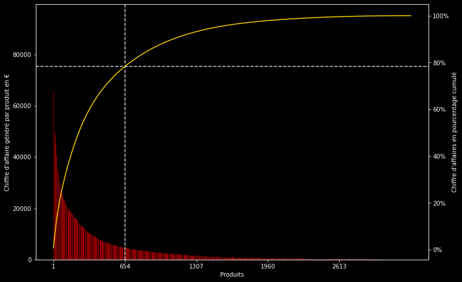

```python
# Afficher la courbe de Pareto pour les produits
fig, ax1 = plt.subplots(figsize=(12,8))
ax1.bar(sales_by_product_sorted.index, sales_by_product_sorted['total_sales_of_product'], color='darkred')
ax1.set_xlabel('Produits')
ax1.set_ylabel('Chiffre d\'affaire généré par produit en €')

ax2 = ax1.twinx()
ax2.plot(percentage_of_sales.index, percentage_of_sales['cum_percentage'], color='gold', ms=7)
ax2.set_ylabel('Chiffre d\'affaires en pourcentage cumulé')
ax2.yaxis.set_major_formatter(PercentFormatter())

# Il y a 3265 produits, 3265 * 0.2 = 653, la tranche des 20% de produits qui génèrent le plus de CA s'arrête donc au 654 ème produit
plt.xticks(np.arange(0, 3265, 653), np.arange(1, 3266, 653))

x_position = sales_by_product_sorted.index[653]  # 654 ème xtick
ax1.axvline(x=x_position, color='lightgray', linestyle='--', label='Ligne verticale')
y_intersection = percentage_of_sales['cum_percentage'].iloc[653]
ax2.axhline(y=y_intersection, color='lightgray', linestyle='--', label='Ligne horizontale')

plt.show()
```

```python
# Récupérer les 20 % de produits qui font quasiment 80 % du CA (environ 77% du CA pour être plus précis)
# et visualiser la proportion de chaque catégorie
sales_by_product.sort_values(by='cumulative_proportion_of_sales', ascending=False, inplace=True)
top_20_percent_products = sales_by_product[sales_by_product['cumulative_proportion_of_sales'] >= 0.23]
top_20_percent_products['categ'].value_counts(normalize=True)
```

```
0    0.438710
1    0.372581
2    0.188710
Name: categ, dtype: float64
```

### Etape 2.6 - Répartition du chiffre d'affaires par type de client

Désormais **il est préférable d'exclure nos 4 clients "pas comme les autres"** pour éviter de biaiser les résultats d'analyse.

```python
# Retirer nos 4 principaux outliers en se servant des id
df_without_outliers = df.loc[~df['client_id'].isin(outliers_id)]
```

```python
# Afficher le nombre de transactions post suppression de ces 4 outliers
df_without_outliers.shape[0]
```

```
640734
```

```python
# Calculer le panier moyen tous clients confondus
mean_order = df_without_outliers.groupby('session_id')['price'].sum().mean()
print('Le panier moyen s\'élève à', round(mean_order,2),'€')
```

```
Le panier moyen s'élève à 34.56 €
```

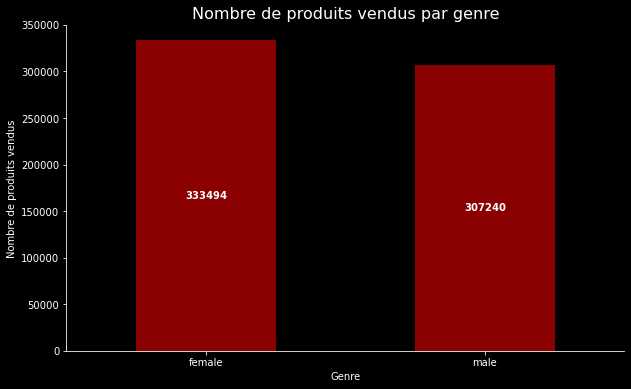

```python
# Visualiser le nombre de transactions réalisées par les hommes et les femmes
plt.figure(figsize=(10, 6))
ax = df_without_outliers['sex'].value_counts().plot(kind='bar', color='darkred')
plt.title('Nombre de produits vendus par genre', fontsize=16)
plt.xlabel('Genre')
plt.ylabel('Nombre de produits vendus')
for p in ax.patches:
    ax.annotate(str(p.get_height()), (p.get_x() + p.get_width() / 2., p.get_height() * 0.50), ha='center', va='center', color='white', fontweight='bold')
ax.spines[['top', 'right']].set_visible(False)
plt.xticks(rotation=0)
ax.set_axisbelow(True)
plt.show()
```

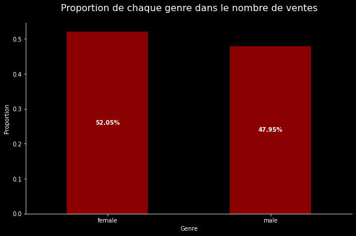

```python
# Visualiser la proportion des deux sexes dans le nombre total de transactions
plt.figure(figsize=(10, 6))
ax = df_without_outliers['sex'].value_counts(normalize=True).plot(kind='bar', color='darkred')
plt.title('Proportion de chaque genre dans le nombre de ventes', fontsize=16, pad=20)
plt.xlabel('Genre')
plt.ylabel('Proportion')

for p in ax.patches:
    ax.annotate("{:.2%}".format(p.get_height()), (p.get_x() + p.get_width() / 2., p.get_height() * 0.50), ha='center', va='center', color='white', fontweight='bold')

ax.spines[['top', 'right']].set_visible(False)
plt.xticks(rotation=0)
ax.set_axisbelow(True)
plt.show()
```

```python
# Créer un dataframe affichant le nombre de connexions (sessions) par sexe
sessions_by_gender = df_without_outliers.groupby('sex')['session_id'].nunique()
sessions_by_gender = sessions_by_gender.reset_index()
sessions_by_gender.columns = ['sex', 'nb_of_unique_sessions']
sessions_by_gender
```

|  | sex | nb_of_unique_sessions |
| --- | --- | --- |
| 0 | female | 168546 |
| 1 | male | 153920 |

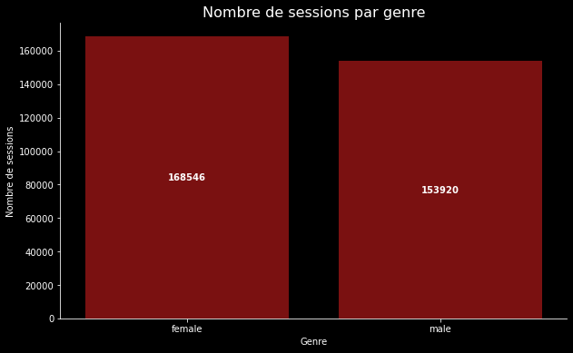

```python
# Visualiser le nombre de connexions (sessions) par sexe
plt.figure(figsize=(10, 6))
ax = sns.barplot(data= sessions_by_gender, x='sex', y='nb_of_unique_sessions', color='darkred')
plt.title('Nombre de sessions par genre', fontsize=16)
plt.xlabel('Genre')
plt.ylabel('Nombre de sessions')
for p in ax.patches:
    ax.annotate(str(f"{p.get_height():.0f}"), (p.get_x() + p.get_width() / 2., p.get_height() * 0.50), ha='center', va='center', color='white', fontweight='bold')
plt.xticks(rotation=0)
ax.set_axisbelow(True)
sns.despine()
plt.show()
```

```python
# Créer un dataframe contenant le montant de chaque panier
average_order_value_of_gender = df_without_outliers.groupby(['sex', 'session_id'])['price'].sum()
average_order_value_of_gender = average_order_value_of_gender.reset_index()
average_order_value_of_gender.columns = ['sex','session_id', 'session_order_value']

average_order_values = {}
for gender in average_order_value_of_gender['sex'].unique():
    average_order_values[gender] = average_order_value_of_gender.loc[average_order_value_of_gender['sex'] == gender, 'session_order_value'].mean()

average_order_values
```

```
{'female': 34.393726816460955, 'male': 34.73519964920725}
```

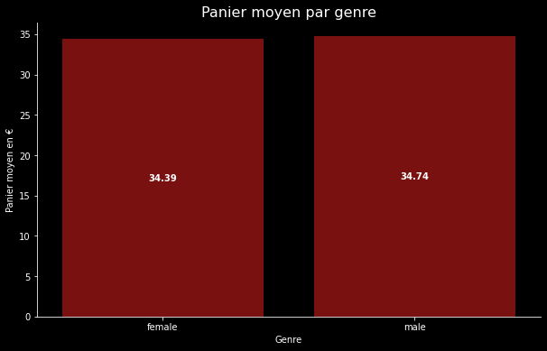

```python
# Convertir le dictionnaire en dataframe
average_order_values = pd.DataFrame(list(average_order_values.items()), columns=['Gender', 'Average_order_value'])

# Visualiser les résultats à l'aide d'un barplot
plt.figure(figsize=(10, 6))
ax = sns.barplot(data=average_order_values, x='Gender', y='Average_order_value', color='darkred')
plt.title('Panier moyen par genre', fontsize=16)
plt.xlabel('Genre')
plt.ylabel('Panier moyen en €')
for p in ax.patches:
    ax.annotate(str(f"{p.get_height():.2f}"), (p.get_x() + p.get_width() / 2., p.get_height() * 0.50), ha='center', va='center', color='white', fontweight='bold')
sns.despine()
plt.show()
```

```python
# Afficher le chiffre d'affaires total par sexe :
sales_by_gender = df_without_outliers.pivot_table(index='sex', values='price', aggfunc=sum)
sales_by_gender = sales_by_gender.reset_index()
sales_by_gender.rename(columns={'sex': 'gender', 'price': 'total_sales'}, inplace=True)
sales_by_gender
```

|  | gender | total_sales |
| --- | --- | --- |
| 0 | female | 5796925.08 |
| 1 | male | 5346441.93 |

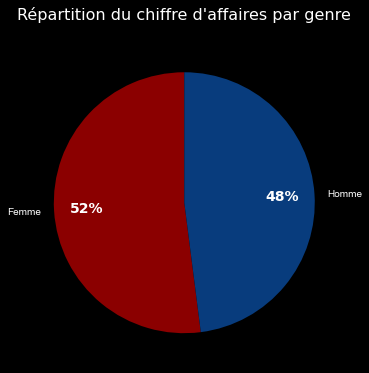

```python
# Visualiser le CA par sexe à l'aide d'un diagramme en secteurs
labels = ['Femme', 'Homme']
palette = sns.color_palette("Blues", n_colors=20).as_hex()[::-1]
first_blue = palette[0]
plt.figure(figsize=(9,6), facecolor='black')
wedges, texts, autotexts = plt.pie(x=sales_by_gender['total_sales'], labels=labels, autopct='%1.0f%%', pctdistance = 0.75, startangle=90, colors=['darkred', first_blue])
plt.title('Répartition du chiffre d\'affaires par genre', fontsize=16, loc='center', pad=20)
plt.setp(autotexts, color='white', weight='bold', size=14)
plt.setp(texts, color='white', family='Arial')
plt.show()
```

Le nombre d'achats est plus ou moins équitablement réparti entre hommes et femmes, tout comme le chiffre d'affaires.  
Cela nous indique que le montant moyen d'un achat ne varie pas ou peu selon le sexe du client.

```python
# Créer un dataframe qui affiche le CA réalisé par tranche d'âge
sales_by_age_group = df_without_outliers.pivot_table(index='age_group', values='price', aggfunc=sum)
sales_by_age_group = sales_by_age_group.reset_index()
sales_by_age_group.rename(columns={'price': 'total_sales'}, inplace=True)

sales_by_age_group['percentage_of_Lapage_revenue'] = round((sales_by_age_group['total_sales'] / sales_by_age_group['total_sales'].sum())*100,2)
sales_by_age_group = sales_by_age_group.sort_values(by='age_group')
sales_by_age_group
```

|  | age_group | total_sales | percentage_of_Lapage_revenue |
| --- | --- | --- | --- |
| 0 | 20-29 | 2419357.60 | 21.71 |
| 1 | 30-39 | 2420859.27 | 21.72 |
| 2 | 40-49 | 2789124.63 | 25.03 |
| 3 | 50-59 | 1719738.81 | 15.43 |
| 4 | 60 and over | 1794286.70 | 16.10 |

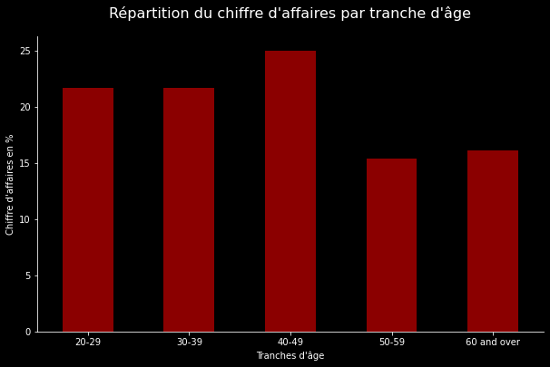

```python
# Visualiser la répartition du chiffre d'affaires par tranche d'âge
plt.figure(figsize=(10, 6))
ax = sales_by_age_group['percentage_of_Lapage_revenue'].plot(kind='bar', color='darkred')
plt.title('Répartition du chiffre d\'affaires par tranche d\'âge', fontsize=16, pad=20)
plt.xlabel('Tranches d\'âge')
plt.ylabel('Chiffre d\'affaires en %')
ax.spines[['top', 'right']].set_visible(False)
plt.xticks(rotation=0)
ax.set_xticklabels(sales_by_age_group['age_group'])
plt.show()
```

```python
# Calculer l'âge moyen des clients
print('Âge moyen des clients:',int(df_without_outliers['age'].mean()),'ans')
```

```
Âge moyen des clients: 46 ans
```

```python
# Créer une colonne CA cumulé
sales_by_age_group['cumulative_sales'] = sales_by_age_group['total_sales'].cumsum()

# Ajouter une colonne proportion cumulée du CA, obtenue en divisant la colonne CA cumulé par le chiffre d'affaires total
sales_by_age_group['cumulative_proportion_of_sales'] = sales_by_age_group['cumulative_sales']/sales_by_age_group['total_sales'].sum()

# Afficher le dataframe
sales_by_age_group
```

|  | age_group | total_sales | percentage_of_Lapage_revenue | cumulative_sales | cumulative_proportion_of_sales |
| --- | --- | --- | --- | --- | --- |
| 0 | 20-29 | 2419357.60 | 21.71 | 2419357.60 | 0.217112 |
| 1 | 30-39 | 2420859.27 | 21.72 | 4840216.87 | 0.434359 |
| 2 | 40-49 | 2789124.63 | 25.03 | 7629341.50 | 0.684653 |
| 3 | 50-59 | 1719738.81 | 15.43 | 9349080.31 | 0.838982 |
| 4 | 60 and over | 1794286.70 | 16.10 | 11143367.01 | 1.000000 |

```python
# Calculer le chiffre d'affaires généré par chaque client sur les deux ans
sales_by_customer = df_without_outliers.pivot_table(index='client_id', values='price', aggfunc=sum)
sales_by_customer = sales_by_customer.reset_index()
sales_by_customer.rename(columns={'price': 'total_sales_of_customer'}, inplace=True)
sales_by_customer = sales_by_customer.sort_values(by='total_sales_of_customer')
sales_by_customer.head()
```

|  | client_id | total_sales_of_customer |
| --- | --- | --- |
| 8326 | 8351 | 6.31 |
| 8116 | 8140 | 8.30 |
| 8090 | 8114 | 9.98 |
| 4632 | 4648 | 11.20 |
| 4462 | 4478 | 13.36 |

```python
# Créer une colonne CA cumulé
sales_by_customer['cumulative_sales'] = sales_by_customer['total_sales_of_customer'].cumsum()

# Ajouter une colonne proportion cumulée du CA, obtenue en divisant la colonne CA cumulé par le chiffre d'affaires total
sales_by_customer['cumulative_proportion_of_sales'] = sales_by_customer['cumulative_sales']/sales_by_customer['total_sales_of_customer'].sum()
# Afficher le dataframe
sales_by_customer
```

|  | client_id | total_sales_of_customer | cumulative_sales | cumulative_proportion_of_sales |
| --- | --- | --- | --- | --- |
| 8326 | 8351 | 6.31 | 6.31 | 5.662561e-07 |
| 8116 | 8140 | 8.30 | 14.61 | 1.311094e-06 |
| 8090 | 8114 | 9.98 | 24.59 | 2.206694e-06 |
| 4632 | 4648 | 11.20 | 35.79 | 3.211776e-06 |
| 4462 | 4478 | 13.36 | 49.15 | 4.410696e-06 |
| ... | ... | ... | ... | ... |
| 7296 | 7319 | 5155.77 | 11122330.09 | 9.981122e-01 |
| 2892 | 2899 | 5214.05 | 11127544.14 | 9.985801e-01 |
| 2134 | 2140 | 5260.18 | 11132804.32 | 9.990521e-01 |
| 3255 | 3263 | 5276.87 | 11138081.19 | 9.995257e-01 |
| 1565 | 1570 | 5285.82 | 11143367.01 | 1.000000e+00 |

8596 rows × 4 columns

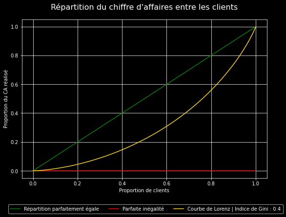

```
0.4
```

```python
# Visualiser la courbe de Lorenz montrant la répartition du CA entre les clients
print(lorenz_curve(sales_by_customer, 'cumulative_proportion_of_sales', 'Proportion de clients', 'Proportion du CA réalisé', 'Répartition du chiffre d\'affaires entre les clients'))
```

La courbe de Lorenz ci-dessus montre que **80 % des clients réalisent environ 55% du chiffre d'affaires**, et les **20 % de clients restant génèrent 45% du CA.**

```python
# Récupérer les 50 % de clients qui font quasiment 80 % du CA
sales_by_customer.sort_values(by='cumulative_proportion_of_sales', ascending=False, inplace=True)
top_50_percent_customers_ids = sales_by_customer.loc[sales_by_customer['cumulative_proportion_of_sales'] >= 0.22, 'client_id'].tolist()
top_50_percent_customers = df_without_outliers.loc[df_without_outliers['client_id'].isin(top_50_percent_customers_ids)]
top_50_percent_customers
```

| transaction_date | id_prod | price | categ | price_group | session_id | client_id | nb_of_products_bought_during_session | sex | year_of_birth | age | age_group |
| --- | --- | --- | --- | --- | --- | --- | --- | --- | --- | --- | --- |
| 2021-03-01 00:01:07.843138 | 0_1259 | 11.99 | 0 | 0-50 | 1 | 329 | 1 | female | 1967 | 57 | 50-59 |
| 2021-03-01 00:02:26.047414 | 0_1390 | 19.37 | 0 | 0-50 | 2 | 664 | 1 | male | 1960 | 64 | 60 and over |
| 2021-03-01 00:02:38.311413 | 0_1352 | 4.50 | 0 | 0-50 | 3 | 580 | 3 | male | 1988 | 36 | 30-39 |
| 2021-03-01 00:04:54.559692 | 0_1458 | 6.55 | 0 | 0-50 | 4 | 7912 | 2 | female | 1989 | 35 | 30-39 |
| 2021-03-01 00:05:18.801198 | 0_1358 | 16.49 | 0 | 0-50 | 5 | 2033 | 1 | female | 1956 | 68 | 60 and over |
| ... | ... | ... | ... | ... | ... | ... | ... | ... | ... | ... | ... |
| 2023-02-28 23:49:03.148402 | 1_508 | 21.92 | 1 | 0-50 | 348444 | 3573 | 1 | female | 1996 | 28 | 20-29 |
| 2023-02-28 23:51:29.318531 | 2_37 | 48.99 | 2 | 0-50 | 348445 | 50 | 1 | female | 1994 | 30 | 30-39 |
| 2023-02-28 23:53:18.929676 | 1_695 | 26.99 | 1 | 0-50 | 348446 | 488 | 1 | female | 1985 | 39 | 30-39 |
| 2023-02-28 23:58:00.107815 | 0_1547 | 8.99 | 0 | 0-50 | 348447 | 4848 | 1 | male | 1953 | 71 | 60 and over |
| 2023-02-28 23:58:30.792755 | 0_1398 | 4.52 | 0 | 0-50 | 348435 | 3575 | 6 | female | 1981 | 43 | 40-49 |

496754 rows × 11 columns

```python
# Afficher le nombre de ces clients
top_50_percent_customers['client_id'].nunique()
```

```
4282
```

```python
# Afficher la répartition des achats de ces clients par sexe et tranche d'âge
gender_age = pd.crosstab(top_50_percent_customers['age_group'], top_50_percent_customers['sex'])
gender_age
```

| sex age_group | female | male |
| --- | --- | --- |
| 20-29 | 23822 | 21548 |
| 30-39 | 62827 | 62518 |
| 40-49 | 91417 | 84435 |
| 50-59 | 44067 | 38643 |
| 60 and over | 36273 | 31204 |

```python
# Afficher la répartition de leurs achats par tranche de prix et par catégorie
price_group_categ = pd.crosstab(top_50_percent_customers['price_group'], top_50_percent_customers['categ'])
price_group_categ
```

| categ price_group | 0 | 1 | 2 |
| --- | --- | --- | --- |
| 0-50 | 307202 | 161493 | 4679 |
| 50-100 | 0 | 1440 | 16527 |
| 100-150 | 0 | 0 | 3265 |
| 150-200 | 0 | 0 | 1423 |
| 200-250 | 0 | 0 | 707 |
| 250-300 | 0 | 0 | 18 |

## Etape 3 - Analyse du comportement des clients

### Etape 3.1 - Lien entre le genre d'un client et les catégories de livres achetés

Les deux variables sont qualitatives. Il s'agit de démontrer s'il existe une corrélation entre le genre d'un client et son attrait pour une catégorie de livres en particulier. Autrement dit si le choix d'une catégorie dépend du sexe ou non. Nous utiliserons le test du **Khi-deux** pour tester l'indépendance des deux variabes.

```python
# Afficher le tableau de contingence entre sex et categ où l'on peut voir le nombre de transactions par genre et par catégorie
contingency_table =  pd.crosstab(df_without_outliers['sex'], df_without_outliers['categ'], margins=True)
contingency_table
```

| categ sex | 0 | 1 | 2 | All |
| --- | --- | --- | --- | --- |
| female | 200793 | 115721 | 16980 | 333494 |
| male | 186488 | 104884 | 15868 | 307240 |
| All | 387281 | 220605 | 32848 | 640734 |

**Les conditions de validité** pour effectuer le test **sont respectées**: les transactions sont indépendantes et les effectifs conjoints dans le tableau de contingence sont tous supérieurs à 5.

```python
# Créer une fonction qui renvoie le tableau des valeurs attendues (effectifs théoriques)
def expected_values(contingency_table):
    # On récupère pour chaque ligne la valeur qui se trouve dans la dernière colonne (colonne total), renvoie autant de valeurs qu'il y a de lignes
    row_totals = contingency_table.iloc[:-1, -1].values

    # On récupère pour chaque colonne la valeur qui se trouve dans la dernière ligne (ligne total), renvoie autant de valeurs qu'il y a de colonnes
    col_totals = contingency_table.iloc[-1, :-1].values

    # On récupère le total des effectifs
    grand_total = contingency_table.values[-1,-1]

    # On initialise un tableau vide (rempli de 0)
    expected_values = np.zeros(contingency_table.shape)

    # pour chaque élément de row_totals
    for i in range(len(row_totals)):
        # et chaque élément de col_totals
        for j in range(len(col_totals)):
            # on multiplie le premier élément de row_totals par chaque élément de col_totals et on divise à chaque fois par l'effectif total
            expected_value = int(np.dot(row_totals[i], col_totals[j]) / grand_total)

            # On ajoute la valeur attendue calculée au numpy array expected_values
            expected_values[i,j] = expected_value

    expected_values_table = pd.DataFrame(expected_values,
                                         index=contingency_table.index,
                                         columns=contingency_table.columns)
    return expected_values_table
```

```python
# Utiliser la fonction pour générer le tableau des effectifs théoriques
expected_table = expected_values(contingency_table)

# La fonction renvoie également la colonne total et la ligne total, on les retire
expected = expected_table.iloc[:-1, :-1]
expected
```

| categ sex | 0 | 1 | 2 |
| --- | --- | --- | --- |
| female | 201574.0 | 114822.0 | 17096.0 |
| male | 185706.0 | 105782.0 | 15751.0 |

```python
# Afficher les valeurs observées histoire de comparer
observed_values = contingency_table.iloc[:-1, :-1]
observed_values
```

| categ sex | 0 | 1 | 2 |
| --- | --- | --- | --- |
| female | 200793 | 115721 | 16980 |
| male | 186488 | 104884 | 15868 |

On pose nos **hypothèses**:  
H0 = Les variables catégorie de livres et genre du client sont indépendantes.  
H1 = Le genre du client a une influence sur le choix de la catégorie de livres achetés.  
A présent calculons la statistique du Khi-deux.

```python
# Créer une fonction qui calcule et renvoie la statistique du khi-deux et qui affiche la heatmap
def Chi_square_and_heatmap(contingency_table, expected_values_table, map_xlabel, map_ylabel):

    # Dépouiller les deux tableaux des marges (ligne Total et colonne Total)
    contingency_table = contingency_table.iloc[:-1, :-1]
    expected_values_table = expected_values_table.iloc[:-1, :-1]

    # Calculer le tableau des erreurs quadratiques moyennes
    # Pour chaque case (effectifs conjoints) du tableau des valeurs observées on calcule : (valeur observée - valeur attendue)² / valeur attendue
    mean_squared_errors = (observed_values - expected)**2 / expected

    # Calculer la somme des erreurs quadratiques moyennes, soit notre statistique Khi-deux
    # mean_squared_errors.sum() calcule la somme des valeurs pour chaque colonne, le deuxième sum() fait la somme de ces sommes
    Chi_square_statistic = mean_squared_errors.sum().sum()

    # Calcul des contributions à la non-indépendance
    # On divise chaque erreur quadratique moyenne par la somme des erreurs quadratiques moyennes (donc par la statistique Khi-deux)
    # afin d'avoir la proportion de chaque erreur dans la contribution totale à la non-indépendance des deux variables qualitatives
    contributions = mean_squared_errors / Chi_square_statistic

    # Générer la heatmap
    plt.figure(figsize=(9,6))
    sns.heatmap(contributions, annot=True, fmt=".2f", cmap="Reds")
    plt.title('Contributions à la non-indépendance des deux variables', fontsize=16, pad=20)
    plt.xlabel(map_xlabel)
    plt.ylabel(map_ylabel)
    plt.show()

    return Chi_square_statistic
```

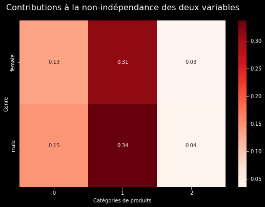

```
22.637123734531478
```

```python
# Afficher la heatmap et la statistique du Khi-deux
Chi_square_statistic = Chi_square_and_heatmap(contingency_table, expected_table, 'Catégories de produits', 'Genre')
Chi_square_statistic
```

Il faut à présent déterminer la valeur critique à laquelle nous allons comparer la statistique Khi-deux. Si cette dernière est supérieure à la valeur critique cela signifie que les écarts  
entre les valeurs observées et les valeurs attendues sont assez significatifs pour rejeter l'hypothèse nulle selon laquelle les deux varibales sont indépendantes.

```python
def Chi_square_critical_and_p_value(contingency_table, alpha, chi_square_statistic):

    # Dépouiller le tableau de contingence de ses marges (ligne total et colonne total)
    observed_values = contingency_table.iloc[:-1, :-1]

    # Calcul des degrés de liberté : (nombre de lignes -1) * (nombre colonnes -1)
    degrees_of_freedom = (observed_values.shape[0]-1) * (observed_values.shape[1]-1)

    # Niveau de significativité choisi
    alpha = alpha

    # Déterminer, à l'aide de la bibliothèque stats de scipy, la valeur critique pour un niveau de confiance 1 - alpha et n degrés de liberté
    # Alternative : utiliser la table du Khi-deux pour déterminer la valeur critique
    critical_value = stats.chi2.ppf(1 - alpha, degrees_of_freedom)

    # Calculer la p-valeur, la probabilité d'obtenir une statistique au moins aussi extrême que celle observée (ici 22.64) si l'hypothèse nulle était vraie
    # Plus la p-valeur est faible plus le résultat obtenu est inhabituel et peu probable sous l'hypothèse nulle
    # Si la p-valeur est inférieure à alpha on rejette cette hypothèse nulle
    p_value = stats.chi2.sf(Chi_square_statistic, degrees_of_freedom)

    return f'Statistique du Khi-deux: {round(Chi_square_statistic,2)}',f'Valeur critique : {round(critical_value,2)}',f'P-valeur : {p_value}'
```

```python
# Afficher le Khi-deux, la valeur critique et la p-valeur
Chi_square_critical_and_p_value(contingency_table, 0.05, Chi_square_statistic)
```

```
('Statistique du Khi-deux: 22.64',
 'Valeur critique : 5.99',
 'P-valeur : 1.2145378058412343e-05')
```

Nous allons **vérifier ces résultats en utilisant la fonction scipy.stats.chi2_contingency()**. Il peut y avoir de légères différences dues au fait que je convertis les valeurs en integers dans la fonction expected_values créée plus haut.

```python
# Vérifier le résultat en utilisant la fonction scipy.stats.chi2_contingency()

# On ne récupère que les valeurs du dataframe
observed_values_array = observed_values.values

chi2, p, dof, expected = stats.chi2_contingency(observed_values_array)

print(f"chi2 statistic:     {chi2}")
print(f"p-value:            {p}")
print(f"degrees of freedom: {dof}")
print("expected frequencies:") # Pour comparer avec les valeurs attendues générées plus haut par la fonction expected_values()
print(expected)
```

```
chi2 statistic:     22.66856665178056
p-value:            1.1955928116587024e-05
degrees of freedom: 2
expected frequencies:
[[201574.89662481 114822.13191434  17096.97146086]
 [185706.10337519 105782.86808566  15751.02853914]]
```

La statistique du Khi-deux (22.64) est supérieure à la valeur critique (5.99), et la p-valeur, probabilité d'observer une statistique aussi extrême si l'hypothèse nulle était vraie, est très faible (ce qui rend la chose hautement improbable) et inférieure au seuil de signification.

**On rejette l'hypothèse nulle. Il semblerait que le sexe d'un client ait une influence sur le choix de la catégorie des livres achetés**.

### Etape 3.2 - Lien entre l'âge des clients et le montant total des achats

L'âge des clients et le montant total des achats sont deux variables quantitatives. Nous évaluerons leur relation en utilisant le **coefficient de corrélation de Pearson** si les conditions suivantes sont respectées:  
**- Chaque variable suit une distribution normale**  
**- Au moins 20 individus dans l'échantillon (recommandé)**  
Autrement nous utiliserons le **coefficent de corrélation de rangs de Spearman**.

```python
# On peut utiliser le dataframe sales_by_customer créé précédemment et auquel il manque juste la variable âge
sales_by_customer.head()
```

|  | client_id | total_sales_of_customer | cumulative_sales | cumulative_proportion_of_sales |
| --- | --- | --- | --- | --- |
| 1565 | 1570 | 5285.82 | 11143367.01 | 1.000000 |
| 3255 | 3263 | 5276.87 | 11138081.19 | 0.999526 |
| 2134 | 2140 | 5260.18 | 11132804.32 | 0.999052 |
| 2892 | 2899 | 5214.05 | 11127544.14 | 0.998580 |
| 7296 | 7319 | 5155.77 | 11122330.09 | 0.998112 |

```python
# Récupérer l'âge de chaque client
client_age = df_without_outliers.pivot_table(index='client_id', values='age')
client_age = client_age.reset_index()
client_age.head()
```

|  | client_id | age |
| --- | --- | --- |
| 0 | 1 | 69 |
| 1 | 2 | 48 |
| 2 | 3 | 45 |
| 3 | 4 | 60 |
| 4 | 5 | 30 |

```python
# Fusion des deux dataframes
sales_by_customer = pd.merge(client_age, sales_by_customer, on='client_id', how='inner')
sales_by_customer = sales_by_customer.sort_values(by='total_sales_of_customer')
sales_by_customer.drop(columns=['cumulative_sales', 'cumulative_proportion_of_sales'], inplace=True)
sales_by_customer.head()
```

|  | client_id | age | total_sales_of_customer |
| --- | --- | --- | --- |
| 8326 | 8351 | 56 | 6.31 |
| 8116 | 8140 | 53 | 8.30 |
| 8090 | 8114 | 62 | 9.98 |
| 4632 | 4648 | 20 | 11.20 |
| 4462 | 4478 | 54 | 13.36 |

```python
# Afficher les dimensions du dataframe sales_by_customer
sales_by_customer.shape
```

```
(8596, 3)
```

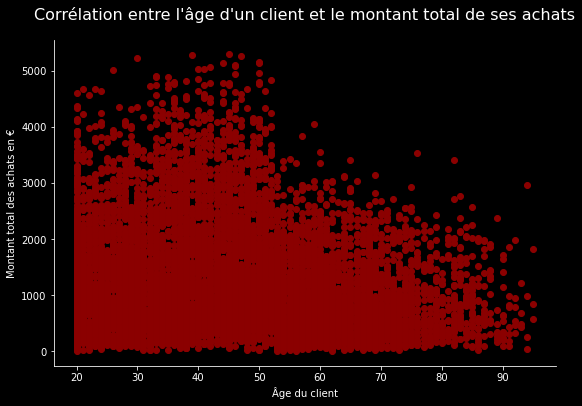

```python
# Visualiser la corrélation entre l'âge des client et le montant total moyen des achats par client à l'aide d'un nuage de points
# on distingue non sans peine une corrélation négative (le montant total des achats tend à diminuer à mesure que l'âge des clients augmente)
plt.figure(figsize=(9,6))
plt.scatter(sales_by_customer['age'], sales_by_customer['total_sales_of_customer'], color='darkred')
plt.title('Corrélation entre l\'âge d\'un client et le montant total de ses achats', fontsize=16, pad=20)
plt.ylabel('Montant total des achats en €')
plt.xlabel('Âge du client')
plt.gca().spines[['right', 'top']].set_visible(False)
plt.show()
```

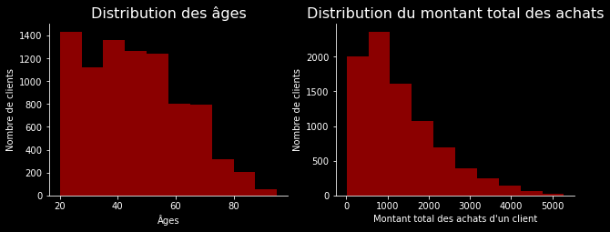

```python
# Visualiser les distributions des deux variables pour déterminer si elles suivent une gaussienne
plt.figure(figsize=(16,16))

plt.subplot(4,3,1)
ax = sales_by_customer['age'].hist(color='darkred')
plt.title('Distribution des âges', fontsize=16)
plt.xlabel('Âges')
plt.ylabel('Nombre de clients')
plt.grid(False)
ax.spines[['top', 'right']].set_visible(False)

plt.subplot(4,3,2)
ax = sales_by_customer['total_sales_of_customer'].hist(color='darkred')
plt.title('Distribution du montant total des achats', fontsize=16)
plt.xlabel('Montant total des achats d\'un client')
plt.ylabel('Nombre de clients')
plt.grid(False)
ax.spines[['top', 'right']].set_visible(False)

plt.show()
plt.tight_layout(pad=3.0)
```

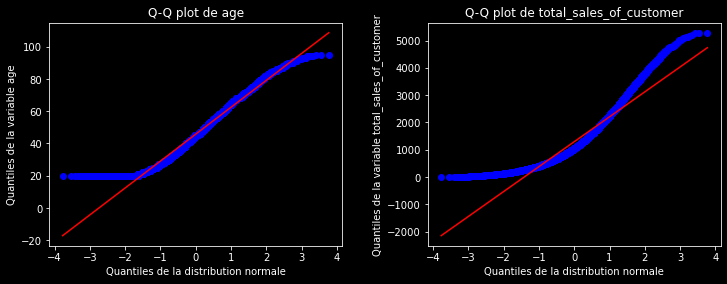

```python
# Visualiser les écarts par rapport à une distribution normale avec un Q-Q plot
# On constate que les observations (en bleu) des deux variables ne s'alignent pas avec la droite
# leur distributions s'écartent de la normalité, c'est plus flagrant pour la variable montant total des achats
plt.figure(figsize=(16,16))

plt.subplot(4,3,1)
stats.probplot(sales_by_customer['age'], dist='norm', plot=plt)
plt.xlabel("Quantiles de la distribution normale")
plt.ylabel("Quantiles de la variable age")
plt.title("Q-Q plot de age")

plt.subplot(4,3,2)
stats.probplot(sales_by_customer['total_sales_of_customer'], dist='norm', plot=plt)
plt.xlabel("Quantiles de la distribution normale")
plt.ylabel("Quantiles de la variable total_sales_of_customer")
plt.title("Q-Q plot de total_sales_of_customer")

plt.tight_layout(pad=3.0)
plt.show()
```

Les données contiennent plus de 20 observations mais les deux distributions ne semblent pas suivre une distribution normale.  
Nous allons effectuer le **test de Kolmogorov-Smirnov** puis celui de **Shapiro-Wilk** pour nous en assurer. **Cela dit, que l'on utilise l'un ou l'autre, les deux tests sont sensibles à la taille de l'échantillon. Plus la taille de l'échantillon est grande moins ces tests sont robustes....**  
Hypothèses:  
H0 : age et total_sales_of_customer suivent une distribution normale  
H1 : les deux distributions ne suivent pas une distribution normale

```python
# Créer une fonction test de normalité qui utilise scipy.stats.kstest() pour effectuer le test de Kolmogorov-Smirnov
def normality_test(df, df_variable, alpha):
    skewness = df[df_variable].skew()

    # Renvoie l'excès de kurtosis (= kurtosis - 3)
    kurtosis = df[df_variable].kurtosis()

    ks_statistic, ks_p_value = stats.kstest(df[df_variable], 'norm')

    # Le test de Shapiro-Wilk est inefficace si taille de l'échantillon est supérieure à 5000
    if len(df[df_variable]) > 5000:
        random_sample = df[df_variable].sample(1000, random_state=42)
        sw_statistic, sw_p_value = stats.shapiro(random_sample)

    if ks_p_value > alpha:
        print(f'Test de Kolmogorov-Smirnov: la variable {df_variable} semble suivre une gaussienne (on ne rejette pas H0)')
    else:
        print(f'Test de Kolmogorov-Smirnov: la variable {df_variable} ne semble pas suivre une gaussienne (on rejette H0)')

    if sw_p_value > alpha:
        print(f'Test de Shapiro-Wilk: la variable {df_variable} semble suivre une gaussienne (on ne rejette pas H0)')
    else:
        print(f'Test de Shapiro-Wilk: la variable {df_variable} ne semble pas suivre une gaussienne (on rejette H0)')

    return f"Skewness: {skewness:.3f} | Excès de Kurtosis: {kurtosis:.3f} | KS Statistique: {ks_statistic:.3f} | KS P-valeur: {ks_p_value:.3f} | SW Statistique: {sw_statistic:.3f} | SW P-valeur: {sw_p_value:.3f}"
```

```python
# Application des tests de Kolmogorov-Smirnov et Shapiro-Wilk à la colonne 'age'
normality_test(sales_by_customer, 'age', 0.05)
```

```
Test de Kolmogorov-Smirnov: la variable age ne semble pas suivre une gaussienne (on rejette H0)
Test de Shapiro-Wilk: la variable age ne semble pas suivre une gaussienne (on rejette H0)
```

```
'Skewness: 0.362 | Excès de Kurtosis: -0.633 | KS Statistique: 1.000 | KS P-valeur: 0.000 | SW Statistique: 0.968 | SW P-valeur: 0.000'
```